# Matplotlib Exercises

Follow the instructions to recreate the plots using this data:

## Data

```python
import numpy as np
import matplotlib.pyplot as plt
x = np.arange(0,100)
y = x*2
z = x**2
```

**Import matplotlib.pyplot as plt and set %matplotlib inline if you are using the jupyter notebook. What command do you use if you aren't using the jupyter notebook?**

```python
plt.show()
```

## Exercise 1

**Follow along with these steps:**

- **Create a figure object called fig using plt.figure()**
- **Use add_axes to add an axis to the figure canvas at [0,0,1,1]. Call this new axis ax.**
- **Plot (x,y) on that axes and set the labels and titles to match the plot below:**

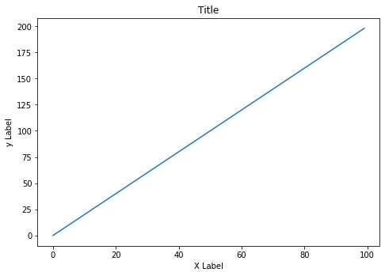

```python
fig = plt.figure()
fig = fig.add_axes([0, 0, 1, 1])
fig.plot(x, y)
fig.set_xlabel('X Label')
fig.set_ylabel('y Label')
fig.set_title('Title')
```

## Exercise 2

**Create a figure object and put two axes on it, ax1 and ax2. Located at [0,0,1,1] and [0.2,0.5,.2,.2] respectively.**

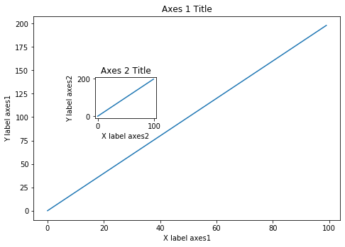

```python
fig = plt.figure()

axes1 = fig.add_axes([0, 0, 1, 1])
axes2 = fig.add_axes([0.2, 0.5, 0.2, 0.2])

axes1.plot(x, y)
axes1.set_xlabel('X label axes1')
axes1.set_ylabel('Y label axes1')
axes1.set_title('Axes 1 Title')

axes2.plot(x, y)
axes2.set_xlabel('X label axes2')
axes2.set_ylabel('Y label axes2')
axes2.set_title('Axes 2 Title')
```

**Now plot (x,y) on both axes. And call your figure object to show it.**

## Exercise 3

**Create the plot below by adding two axes to a figure object at [0,0,1,1] and [0.2,0.5,.4,.4]**

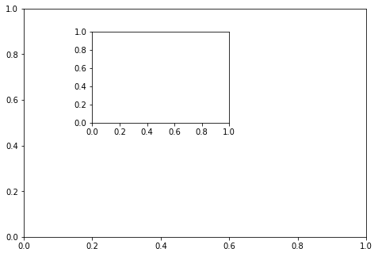

```python
fig = plt.figure()

axes1 = fig.add_axes([0, 0, 1, 1])
axes2 = fig.add_axes([0.2, 0.5, 0.4, 0.4])
```

**Now use x,y, and z arrays to recreate the plot below. Notice the xlimits and y limits on the inserted plot:**

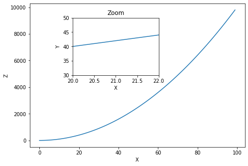

```python
fig = plt.figure()

axes1 = fig.add_axes([0, 0, 1, 1])
axes2 = fig.add_axes([0.2, 0.5, 0.4, 0.4])

axes1.plot(x, z)
axes1.set_xlabel('X')
axes1.set_ylabel('Z')

axes2.plot(x, y)
axes2.set_xlim([20, 22])
axes2.set_ylim([30, 50])
axes2.set_xlabel('X')
axes2.set_ylabel('Y')
axes2.set_title('Zoom')
```

## Exercise 4

**Use plt.subplots(nrows=1, ncols=2) to create the plot below.**

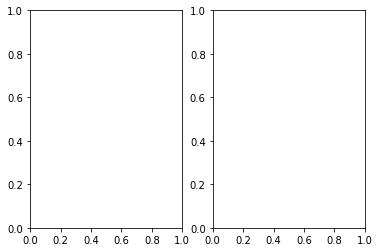

```python
fig, axes = plt.subplots(nrows=1, ncols=2)
```

**Now plot (x,y) and (x,z) on the axes. Play around with the linewidth and style**

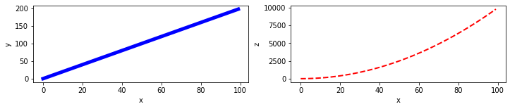

```python
fig, axes = plt.subplots(nrows=1, ncols=2, figsize = (12, 2))

axes[0].plot(x, y, color = "blue", lw = 5)
axes[0].set_xlabel('x')
axes[0].set_ylabel('y')

axes[1].plot(x, z, color = "red", lw = 2, ls = '--')
axes[1].set_xlabel('x')
axes[1].set_ylabel('z')
```

**See if you can resize the plot by adding the figsize() argument in plt.subplots() are copying and pasting your previous code.**

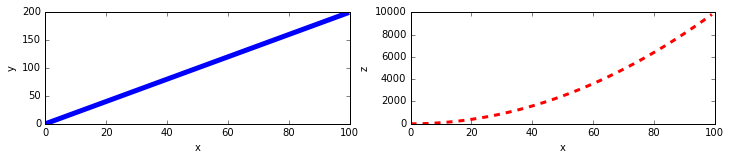